# Get started with open reproducible science! (API version) 🌏 📈

**Define Open Reproducible Science:** Open reproduceible science makes the process of scientific research available to all in a way that anyone can access, understand and iterate the process. This allows to share and colaborate the methods,data, and outcomes easily with transparency. Simply, open reproducible science is a way of doing research which others can access,understand and replicate without any boundation. It makes the entire process transparent and ensures that results are available freely.  
**Choose one of the open source tools that you have learned about (i.e. Shell, Git/GitHub, Jupyter Notebook, Python) and explain how it supports open reproducible science:** Github provides a platform where we can share and collaborate on our code and discuss issues about it. This course provided me to understand and learn hands on python code with applications in Geospatial domain via Git which is shareable, replicable, and available freely.

**Does this Jupyter Notebook file have a machine-readable name? Explain your answer.**  
Yes, this Jupyter notebook has a machine readable name Reproducible Science! with the extension .ipynb. However, to make the file name easy to read and parse, we should avoid other special charecters except dash or underscore to separate words. The filename has been changed to Bangalore_TimeSeries.ipynb by removing the special charecter '!' and using underscore between the names.

# Suggestions for creating readable, well-documented scientific workflows that are easier to reproduce

**I can write clean code by:**  
a) Following the standard syntax  
b) Creating meaningful variable and function names  
c) Using modular programming  
d) Proper documentation

**Advantages of clean code include:**  
a) Easy to find logical errors in dev environment  
b) Easy to maintain the code in production environment  
c) Easily readable and understandable  
d) Makes the code reusable  
e) Helps in code fixes and further enhancements

# Assignment : Climate Coding Challenge

**Study Area: Bengaluru, India**  
Bengaluru also known as Bangalore lies in the southeast of the South Indian state of Karnataka at an elevation of 921 m. It covers an area of 741 square kms. Bangalore has a tropical savanna climate with distinct wet and dry seasons. Due to its high elevation, Bangalore has a moderate climate throughout the year, although occasional heat waves can make summer hotter.

I am using data from the NOAA NCEI Climate Data Online network (network ID: GHCND:IN009010100).

[figure not shown]

**Data: Precipitation and Temperature Dataset from 1901-2024**

**API used : National Centers for Environmental Information (NCEI), NOAA website**  
**url: https://www.ncei.noaa.gov/**

```python
import pandas as pd
```

```python
bng_ind_url = ('https://www.ncei.noaa.gov/access/services/da'
    'ta/v1?dataset=daily-summaries&dataTypes=TAVG,TMAX,TMIN,PRCP'
    '&stations=IN009010100&startDate=1901-01-01&endDate=2024-04-15&'
    'includeStationName=true&includeStation'
    'Location=1&units=metric')
bng_ind_url
```

```
'https://www.ncei.noaa.gov/access/services/data/v1?dataset=daily-summaries&dataTypes=TAVG,TMAX,TMIN,PRCP&stations=IN009010100&startDate=1901-01-01&endDate=2024-04-15&includeStationName=true&includeStationLocation=1&units=metric'
```

```python
bgl_ind_df = pd.read_csv(
  bng_ind_url,index_col='DATE',parse_dates=True,na_values=['NaN'])
bgl_ind_df
```

| DATE | STATION | NAME | LATITUDE | LONGITUDE | ELEVATION | PRCP | TAVG | TMAX | TMIN |
| --- | --- | --- | --- | --- | --- | --- | --- | --- | --- |
| 1901-01-01 | IN009010100 | BANGALORE, IN | 12.967 | 77.583 | 921.0 | 0.0 | NaN | NaN | NaN |
| 1901-01-02 | IN009010100 | BANGALORE, IN | 12.967 | 77.583 | 921.0 | 0.0 | NaN | NaN | NaN |
| 1901-01-03 | IN009010100 | BANGALORE, IN | 12.967 | 77.583 | 921.0 | 0.0 | NaN | NaN | NaN |
| 1901-01-04 | IN009010100 | BANGALORE, IN | 12.967 | 77.583 | 921.0 | 0.0 | NaN | NaN | NaN |
| 1901-01-05 | IN009010100 | BANGALORE, IN | 12.967 | 77.583 | 921.0 | 0.0 | NaN | NaN | NaN |
| ... | ... | ... | ... | ... | ... | ... | ... | ... | ... |
| 2024-04-11 | IN009010100 | BANGALORE, IN | 12.967 | 77.583 | 921.0 | NaN | 29.0 | 36.0 | 21.6 |
| 2024-04-12 | IN009010100 | BANGALORE, IN | 12.967 | 77.583 | 921.0 | NaN | 28.9 | 35.8 | 22.6 |
| 2024-04-13 | IN009010100 | BANGALORE, IN | 12.967 | 77.583 | 921.0 | NaN | 29.3 | 34.6 | 22.5 |
| 2024-04-14 | IN009010100 | BANGALORE, IN | 12.967 | 77.583 | 921.0 | NaN | 29.6 | 35.4 | 22.3 |
| 2024-04-15 | IN009010100 | BANGALORE, IN | 12.967 | 77.583 | 921.0 | NaN | 28.9 | 35.4 | 22.0 |

43275 rows × 9 columns

```python
# Check that the data was imported into a pandas DataFrame
type(bgl_ind_df)
```

```
pandas.core.frame.DataFrame
```

```python
bgl_ind_df = bgl_ind_df[['PRCP', 'TAVG','TMAX','TMIN']]
bgl_ind_df
```

| DATE | PRCP | TAVG | TMAX | TMIN |
| --- | --- | --- | --- | --- |
| 1901-01-01 | 0.0 | NaN | NaN | NaN |
| 1901-01-02 | 0.0 | NaN | NaN | NaN |
| 1901-01-03 | 0.0 | NaN | NaN | NaN |
| 1901-01-04 | 0.0 | NaN | NaN | NaN |
| 1901-01-05 | 0.0 | NaN | NaN | NaN |
| ... | ... | ... | ... | ... |
| 2024-04-11 | NaN | 29.0 | 36.0 | 21.6 |
| 2024-04-12 | NaN | 28.9 | 35.8 | 22.6 |
| 2024-04-13 | NaN | 29.3 | 34.6 | 22.5 |
| 2024-04-14 | NaN | 29.6 | 35.4 | 22.3 |
| 2024-04-15 | NaN | 28.9 | 35.4 | 22.0 |

43275 rows × 4 columns

**Ploting the precpitation column (PRCP) and Temperature columns (TAVG,TMAX,TMIN) vs time**

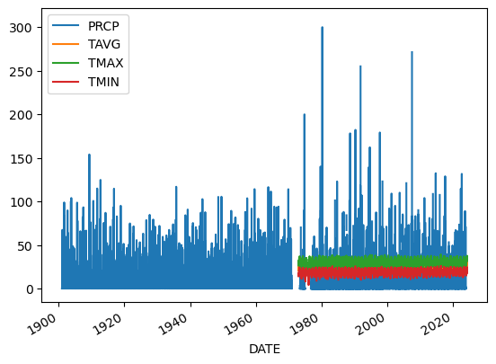

```python
bgl_ind_df.plot()
```

**Ploting the precpitation column (PRCP) vs time**

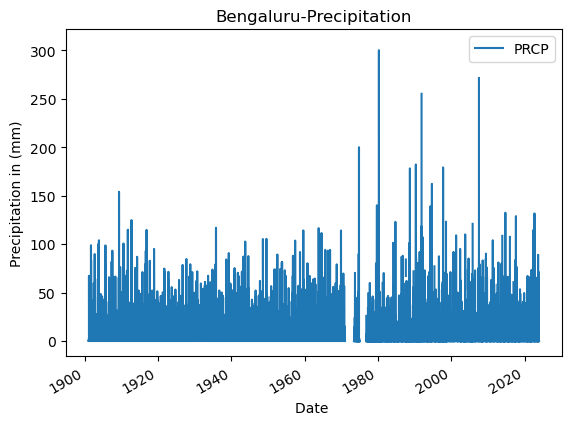

```python
bgl_ind_df.plot(
    y='PRCP',
    title='Bengaluru-Precipitation',
    xlabel='Date ',
    ylabel='Precipitation in (mm)')
```

**Plotting Average Temperature vs Time**

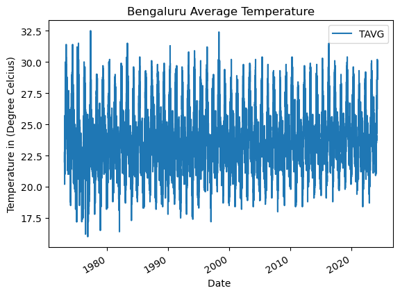

```python
# Plot the temperature vs time
bgl_ind_df.plot(
    y='TAVG',
    title='Bengaluru Average Temperature',
    xlabel='Date ',
    ylabel='Temperature in (Degree Celcius)'
)
```

**Converting TAVG temperature values to Fahrenheit from Celcius**

```python
# Convert to Fahrenheit from Celcius
# Considering the average temperature (TAVG)
bgl_ind_df.loc[:,'TFah'] = (bgl_ind_df.loc[:,'TAVG'] * (9/5) ) + 32
bgl_ind_df
```

| DATE | PRCP | TAVG | TMAX | TMIN | TFah |
| --- | --- | --- | --- | --- | --- |
| 1901-01-01 | 0.0 | NaN | NaN | NaN | NaN |
| 1901-01-02 | 0.0 | NaN | NaN | NaN | NaN |
| 1901-01-03 | 0.0 | NaN | NaN | NaN | NaN |
| 1901-01-04 | 0.0 | NaN | NaN | NaN | NaN |
| 1901-01-05 | 0.0 | NaN | NaN | NaN | NaN |
| ... | ... | ... | ... | ... | ... |
| 2024-04-11 | NaN | 29.0 | 36.0 | 21.6 | 84.20 |
| 2024-04-12 | NaN | 28.9 | 35.8 | 22.6 | 84.02 |
| 2024-04-13 | NaN | 29.3 | 34.6 | 22.5 | 84.74 |
| 2024-04-14 | NaN | 29.6 | 35.4 | 22.3 | 85.28 |
| 2024-04-15 | NaN | 28.9 | 35.4 | 22.0 | 84.02 |

43275 rows × 5 columns

**Writing Python Function to convert temperature values from Celcius to Fahrenheit**

```python
def convert_to_fahrenheit(celcius):
    """Convert temperature to fahrenheit"""
    return ((9/5 * celcius) + 32)

bgl_ind_df['fahrenheit_column'] = bgl_ind_df['TAVG'].apply(convert_to_fahrenheit)
bgl_ind_df
```

| DATE | PRCP | TAVG | TMAX | TMIN | TFah | fahrenheit_column |
| --- | --- | --- | --- | --- | --- | --- |
| 1901-01-01 | 0.0 | NaN | NaN | NaN | NaN | NaN |
| 1901-01-02 | 0.0 | NaN | NaN | NaN | NaN | NaN |
| 1901-01-03 | 0.0 | NaN | NaN | NaN | NaN | NaN |
| 1901-01-04 | 0.0 | NaN | NaN | NaN | NaN | NaN |
| 1901-01-05 | 0.0 | NaN | NaN | NaN | NaN | NaN |
| ... | ... | ... | ... | ... | ... | ... |
| 2024-04-11 | NaN | 29.0 | 36.0 | 21.6 | 84.20 | 84.20 |
| 2024-04-12 | NaN | 28.9 | 35.8 | 22.6 | 84.02 | 84.02 |
| 2024-04-13 | NaN | 29.3 | 34.6 | 22.5 | 84.74 | 84.74 |
| 2024-04-14 | NaN | 29.6 | 35.4 | 22.3 | 85.28 | 85.28 |
| 2024-04-15 | NaN | 28.9 | 35.4 | 22.0 | 84.02 | 84.02 |

43275 rows × 6 columns

**Subsetting and Resampling the data (1980-2024)**

```python
# Subset the data to look at 1980-2024
bgl_ind_1980_2024_df = bgl_ind_df.loc['1980-01-01':'2024-04']
bgl_ind_1980_2024_df
```

| DATE | PRCP | TAVG | TMAX | TMIN | TFah | fahrenheit_column |
| --- | --- | --- | --- | --- | --- | --- |
| 1980-01-01 | 0.0 | 20.0 | 30.0 | 14.0 | 68.00 | 68.00 |
| 1980-01-02 | NaN | 21.0 | 28.0 | NaN | 69.80 | 69.80 |
| 1980-01-03 | 0.0 | 21.4 | 28.0 | 15.0 | 70.52 | 70.52 |
| 1980-01-04 | 0.0 | 20.7 | 28.0 | 15.0 | 69.26 | 69.26 |
| 1980-01-05 | 0.0 | 20.3 | 27.0 | 15.0 | 68.54 | 68.54 |
| ... | ... | ... | ... | ... | ... | ... |
| 2024-04-11 | NaN | 29.0 | 36.0 | 21.6 | 84.20 | 84.20 |
| 2024-04-12 | NaN | 28.9 | 35.8 | 22.6 | 84.02 | 84.02 |
| 2024-04-13 | NaN | 29.3 | 34.6 | 22.5 | 84.74 | 84.74 |
| 2024-04-14 | NaN | 29.6 | 35.4 | 22.3 | 85.28 | 85.28 |
| 2024-04-15 | NaN | 28.9 | 35.4 | 22.0 | 84.02 | 84.02 |

16036 rows × 6 columns

```python
# Resample the data to look at yearly mean values
bgl_ind_yearly_mean = bgl_ind_1980_2024_df.resample('YS-May').mean()
bgl_ind_yearly_mean
```

| DATE | PRCP | TAVG | TMAX | TMIN | TFah | fahrenheit_column |
| --- | --- | --- | --- | --- | --- | --- |
| 1979-05-01 | 2.986792 | 24.210744 | 31.276190 | 18.041667 | 75.579339 | 75.579339 |
| 1980-05-01 | 2.149355 | 23.731680 | 29.747604 | 18.833333 | 74.717025 | 74.717025 |
| 1981-05-01 | 1.909635 | 23.357300 | 29.555340 | 18.880427 | 74.043140 | 74.043140 |
| 1982-05-01 | 1.599344 | 24.100284 | 30.163729 | 19.156641 | 75.380511 | 75.380511 |
| 1983-05-01 | 3.018153 | 23.490808 | 29.018000 | 19.153759 | 74.283454 | 74.283454 |
| 1984-05-01 | 1.368301 | 23.718733 | 29.847516 | 18.776254 | 74.693719 | 74.693719 |
| 1985-05-01 | 1.292208 | 23.377500 | 29.532381 | 18.859364 | 74.079500 | 74.079500 |
| 1986-05-01 | 4.331392 | 23.689779 | 29.506462 | 18.811847 | 74.641602 | 74.641602 |
| 1987-05-01 | 2.274760 | 23.998892 | 29.813770 | 19.321453 | 75.198006 | 75.198006 |
| 1988-05-01 | 2.764169 | 23.545326 | 29.605694 | 18.791078 | 74.381586 | 74.381586 |
| 1989-05-01 | 2.824437 | 23.769337 | 29.649836 | 18.896377 | 74.784807 | 74.784807 |
| 1990-05-01 | 1.676897 | 23.751003 | 29.561842 | 19.209025 | 74.751805 | 74.751805 |
| 1991-05-01 | 3.917940 | 23.228169 | 29.040717 | 18.465414 | 73.810704 | 73.810704 |
| 1992-05-01 | 2.066238 | 23.389972 | 29.409627 | 18.600000 | 74.101950 | 74.101950 |
| 1993-05-01 | 2.938801 | 23.650139 | 29.374121 | 18.926736 | 74.570249 | 74.570249 |
| 1994-05-01 | 2.274154 | 23.470914 | 29.149045 | 19.011034 | 74.247645 | 74.247645 |
| 1995-05-01 | 3.023279 | 23.840997 | 29.788000 | 18.920847 | 74.913795 | 74.913795 |
| 1996-05-01 | 2.972277 | 23.367787 | 29.450156 | 19.009894 | 74.062017 | 74.062017 |
| 1997-05-01 | 3.340127 | 24.263085 | 30.514241 | 20.082332 | 75.673554 | 75.673554 |
| 1998-05-01 | 5.394643 | 23.964463 | 29.878466 | 19.394444 | 75.136033 | 75.136033 |
| 1999-05-01 | 3.841799 | 23.465193 | 29.458333 | 19.131987 | 74.237348 | 74.237348 |
| 2000-05-01 | 8.882812 | 23.564110 | 29.577746 | 19.056579 | 74.415397 | 74.415397 |
| 2001-05-01 | 5.906061 | 23.779178 | 29.766181 | 19.242628 | 74.802521 | 74.802521 |
| 2002-05-01 | 2.144444 | 24.133425 | 30.470605 | 19.430968 | 75.440166 | 75.440166 |
| 2003-05-01 | 2.027900 | 24.130411 | 30.660299 | 19.349032 | 75.434740 | 75.434740 |
| 2004-05-01 | 3.343614 | 23.390137 | 29.420950 | 18.975321 | 74.102247 | 74.102247 |
| 2005-05-01 | 8.056771 | 23.522466 | 29.568555 | 19.049684 | 74.340438 | 74.340438 |
| 2006-05-01 | 5.482569 | 23.938904 | 30.100281 | 19.279755 | 75.090027 | 75.090027 |
| 2007-05-01 | 8.857862 | 23.570799 | 29.414571 | 19.208091 | 74.427438 | 74.427438 |
| 2008-05-01 | 7.975172 | 23.784110 | 29.924011 | 19.114634 | 74.811397 | 74.811397 |
| 2009-05-01 | 7.068085 | 24.141758 | 29.923034 | 19.673209 | 75.455165 | 75.455165 |
| 2010-05-01 | 6.247368 | 23.710685 | 29.531476 | 19.455937 | 74.679233 | 74.679233 |
| 2011-05-01 | 5.211429 | 23.797507 | 30.409722 | 19.309091 | 74.835512 | 74.835512 |
| 2012-05-01 | 5.314286 | 24.285753 | 30.968956 | 19.567492 | 75.714356 | 75.714356 |
| 2013-05-01 | 6.118343 | 23.774521 | 30.210137 | 19.502572 | 74.794137 | 74.794137 |
| 2014-05-01 | 7.795122 | 23.889863 | 30.270959 | 19.380328 | 75.001753 | 75.001753 |
| 2015-05-01 | 5.883951 | 24.392623 | 30.613960 | 20.054517 | 75.906721 | 75.906721 |
| 2016-05-01 | 4.855782 | 24.260548 | 30.901290 | 19.514590 | 75.668986 | 75.668986 |
| 2017-05-01 | 9.550000 | 24.094521 | 30.370890 | 19.572188 | 75.370137 | 75.370137 |
| 2018-05-01 | 5.368493 | 24.214521 | 30.422368 | 19.727692 | 75.586137 | 75.586137 |
| 2019-05-01 | 4.847368 | 24.361475 | 30.606977 | 20.058576 | 75.850656 | 75.850656 |
| 2020-05-01 | 6.039785 | 23.961219 | 30.132168 | 19.729043 | 75.130194 | 75.130194 |
| 2021-05-01 | 7.696111 | 23.917534 | 29.929293 | 19.930868 | 75.051562 | 75.051562 |
| 2022-05-01 | 9.674302 | 23.647527 | 29.496497 | 19.271154 | 74.565549 | 74.565549 |
| 2023-05-01 | 6.725532 | 24.627616 | 30.688060 | 20.342424 | 76.329709 | 76.329709 |

> **Plot your resampled data 📈**

```python
# Plot mean annual temperature values
# using hvplot
import hvplot.pandas
(bgl_ind_1980_2024_df.hvplot(
    y='TAVG',
    title='Bengaluru Mean Annual Temperature',
    xlabel='DATE',
    ylabel='Temperature in (C)')
+
bgl_ind_yearly_mean.hvplot(
    y='TAVG',
    title='Bengaluru Mean Annual Temperature',
    xlabel='DATE',
    ylabel='Temperature in (C)',shared_axes=False)).cols(1)
```

[output not shown]

```python
# Plot Annual Max temperature values
# using hvplot
import hvplot.pandas
(bgl_ind_1980_2024_df.hvplot(
    y='TMAX',
    title='Bengaluru Annual Maximum Temperature',
    xlabel='DATE',
    ylabel='Temperature in (C)')
+
bgl_ind_yearly_mean.hvplot(
    y='TMAX',
    title='Bengaluru Annual Maximum Temperature',
    xlabel='DATE',
    ylabel='Temperature in (C)',shared_axes=False)).cols(1)
```

[output not shown]

```python
%%capture
%%bash
#Coverting to HTML
jupyter nbconvert Bangalore_TimeSeries.ipynb --to html
```